# Part II - FIVE TAKEAWAYS FROM PISA 2012 ANALYSIS

## by (Anas Azzioui)

## Investigation Overview

In this investigation, I want to take a closer look at what features help students score better at math.

- What are the learning strategies used by the highest scorers?
- What are their work ethics?
- Are there any behaviors that favorites them?

  and more answers to find as we go on. I intend to retrieve 5 insights from students who scored an average math score of 600 or higher, which should help any student become better at math.

## Dataset Overview

PISA is a Program for International Student Assessment that assesses 15 years old students' competencies in 3 main subjects: mathematics, science and reading. It is conducted every 3 years, and each time the focus is on one of the subjects. In 2012, the focus was on mathematics, which means, students got more questions math-related. Alongside the assessments, PISA gather a lot of information about many features related especially to students, parents, teachers and schools.

## Correlation between math, science and reading average scores:

Mean scores of math,reading and science are strongly, positively correlated with one another. This means that a student who is good at math is usually also good at reading and science. Later, in this presentation, we will focus only on one of disciplines which is mathematics.

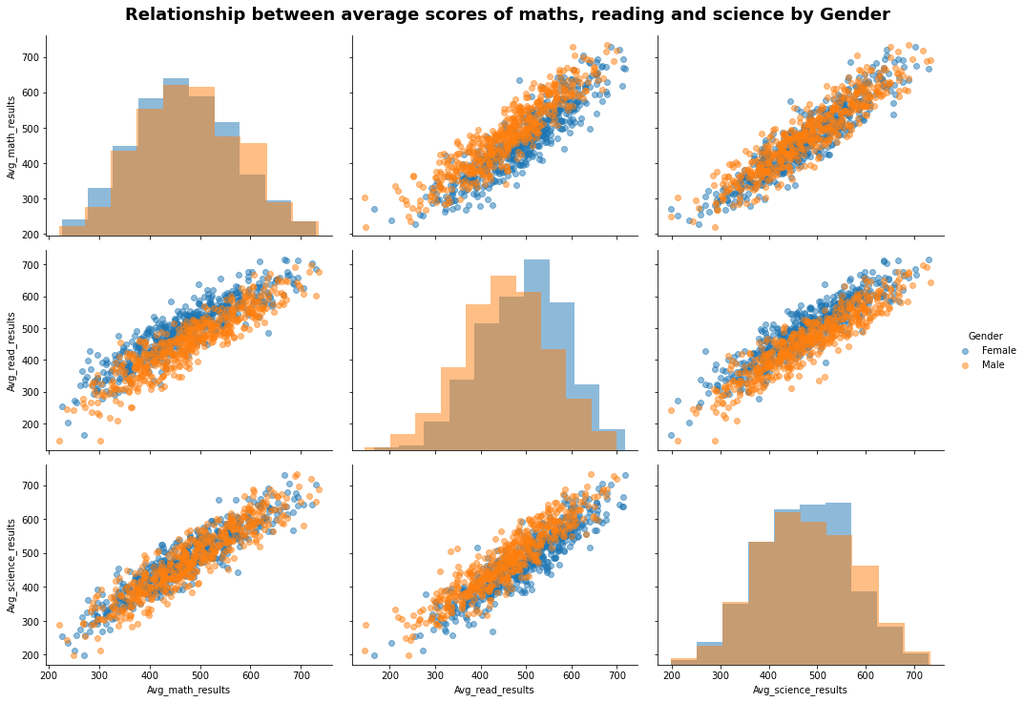

## Distribution of math scores for all countries:

The following plot shows that the math's average score among students of all countries is normally distributed, with the highest number of students having an average score above 400 and less than 500.

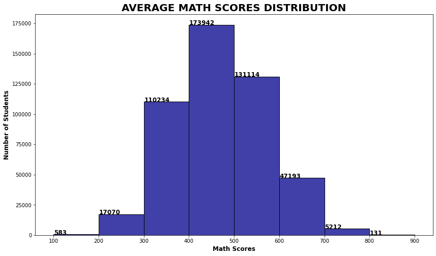

## STUDENTS' GRADES DISTRIBUTION:

PISA assesses students that are 15 years old whatever grade they are in. So it's worth taking into consideration that some student studied more math concepts than others. Let's see the grades distribution of students:

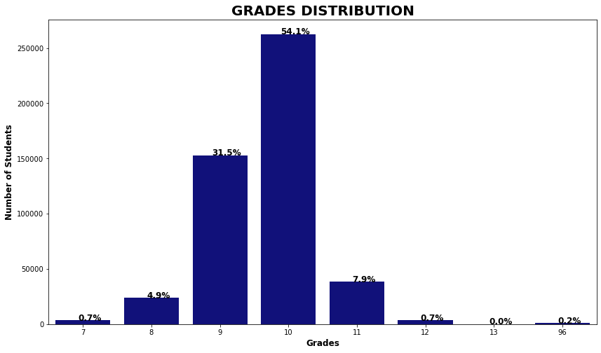

## ABSENTEEISM VS SCORES:

In Truancy, we try to analyse 3 aspects from student's perspective:

```
- How often being late to school
- How often skipping classes within school day
- How often skipping the whole school day
```

When we analyse the visualization, it is clear that the median of scores of students who are never late, never skip classes or school days is significantly higher than the others. Also, we notice, the more often the students are late, skip classes or skip school days the worst their scores are.

#### 1. Being late to school

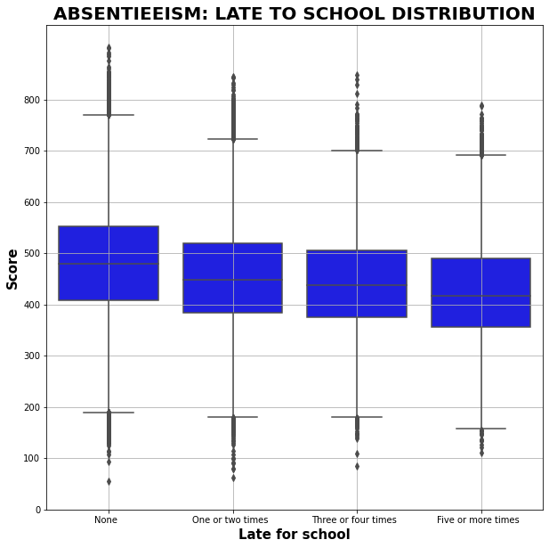

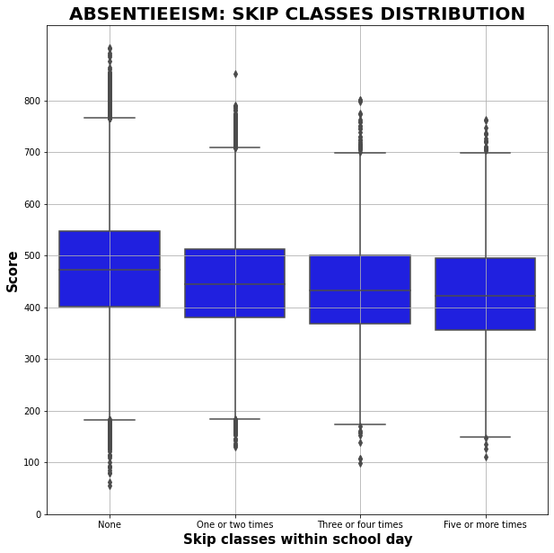

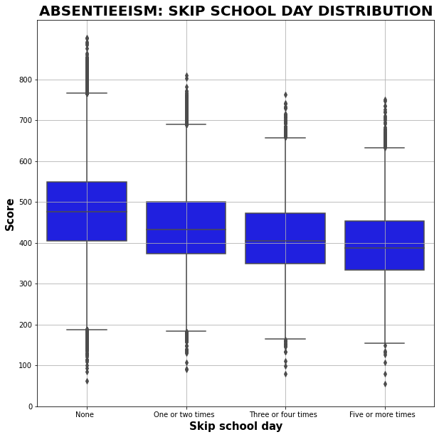

## BEING INTERESTED IN MATH VS SCORES:

The number of students who strongly agree being interested in MATH in general, Math lessons in particular, reading or generally enjoying math is, ironically at the same time, higher among those scoring above 600 more than in the other categories and also slightly higher among those scoring less than 300 compared to other categories.

Also, we notice that statistically, we can't claim there is any obvious correlation between being interested in math and having good or bad scores in it.

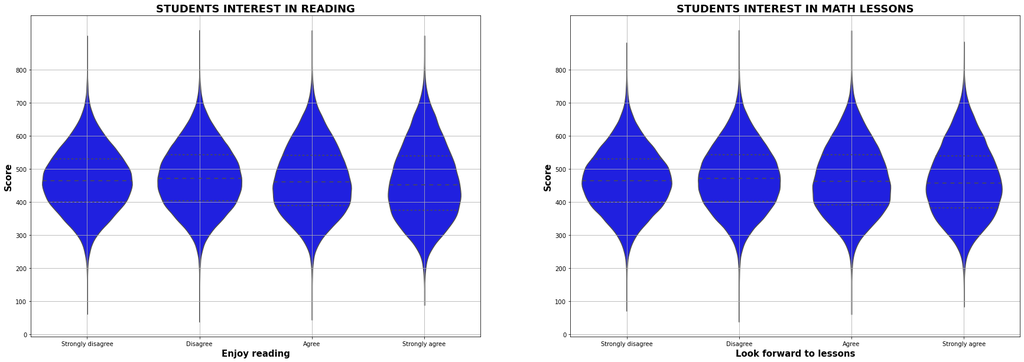

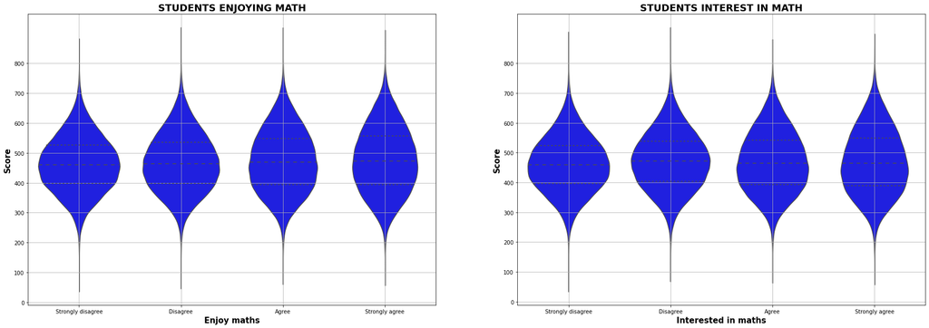

## STUDENT WORKING ETHICS VS SCORES:

The graphs show that the median of scores is slightly higher for students who have strong different work ethics, especially in what concern paying attention in classes and completing given homeworks on time.

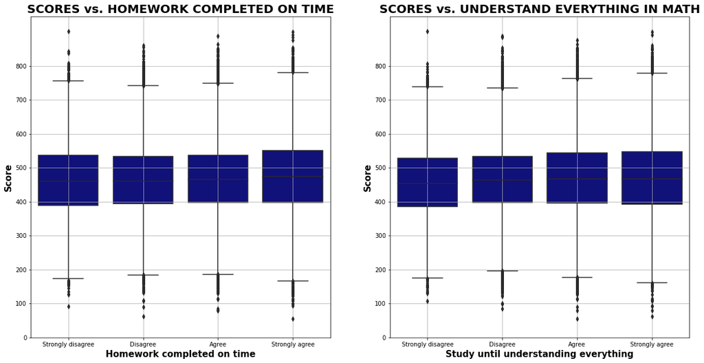

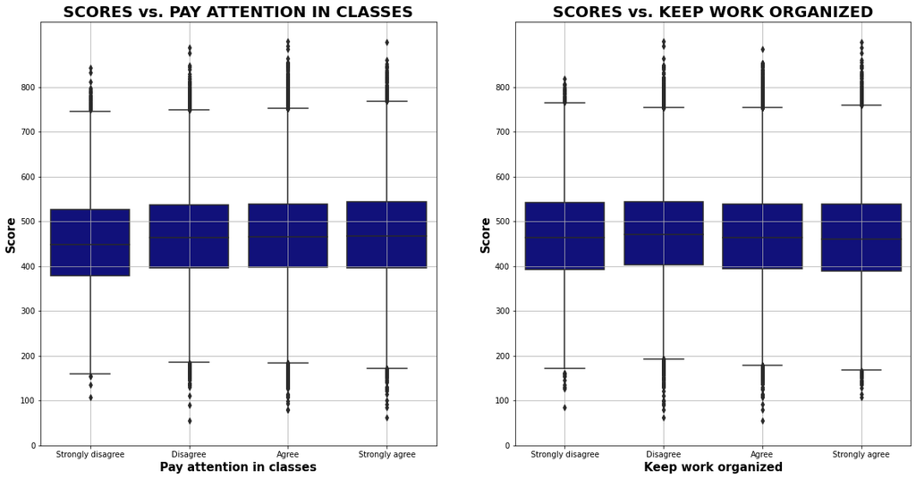

## PARENTS INTERESTED IN MATH VS STUDENTS' SCORES:

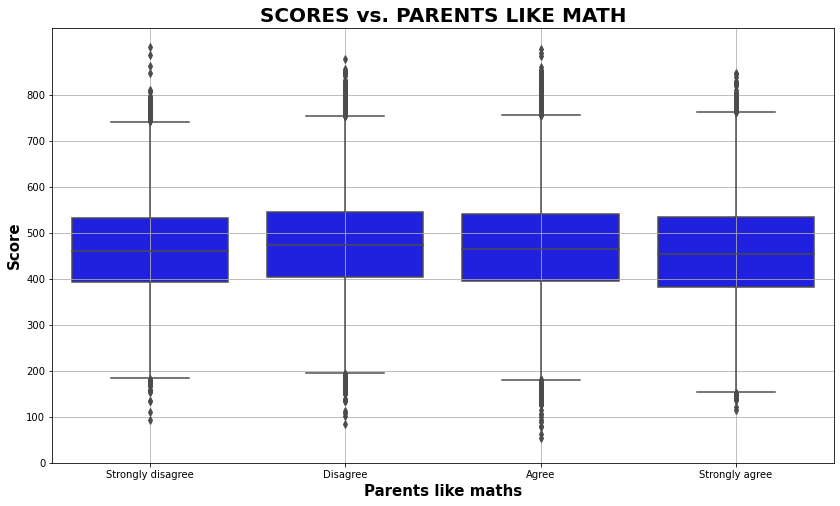

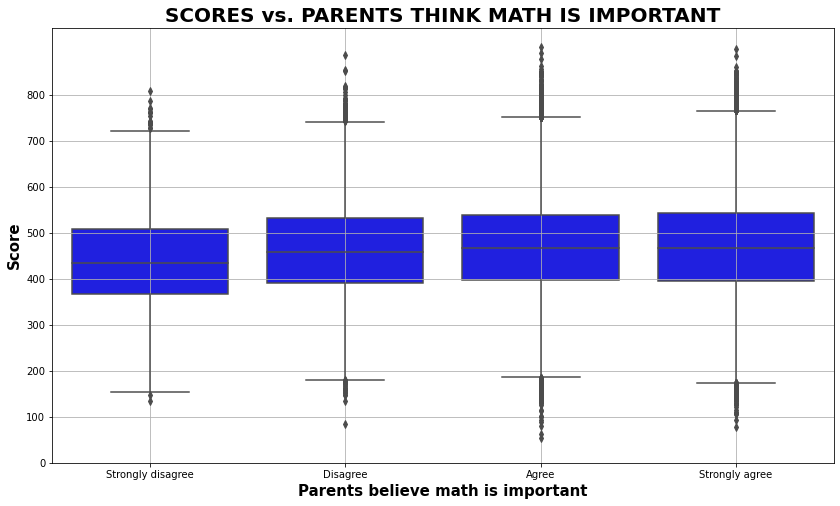

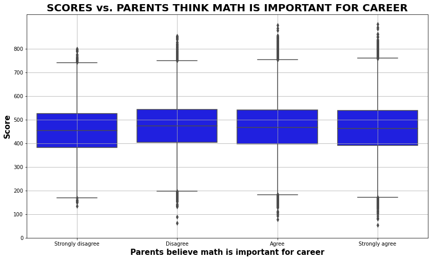

## MATH LEARNING STRATEGIES VS SCORES:

In total, we have analyzed 12 learning strategies and we have noticed that there isn't a certain strategy that was clearly differentiated from the others. Students with high and low scores used the same strategies. With that said, here are the 3 best and 2 worst learning strategies in terms of the score median:

- The 3 best learning strategies:
  - Relating to known
  - Improve understanding
  - Seeking more information
- The 2 worst learning strategies:
  - Learn by heart
  - Find new ways

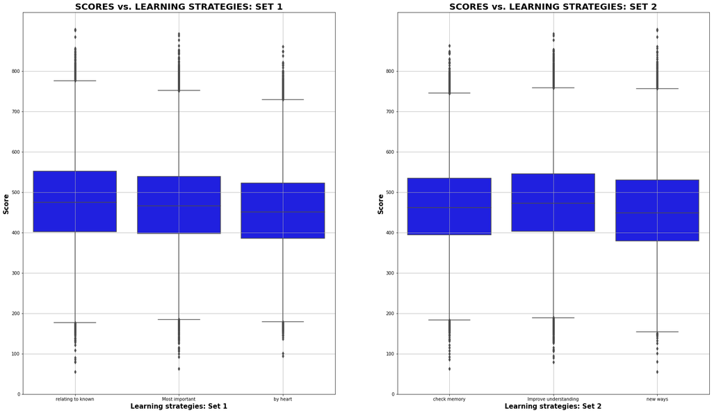

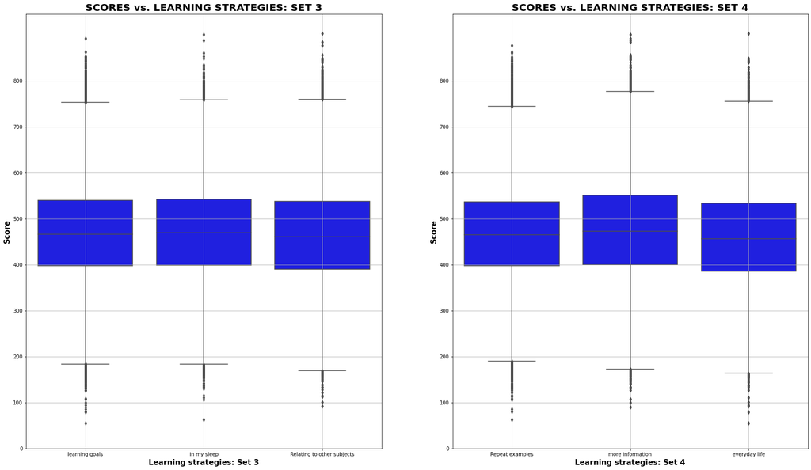